# A/B Test Subscription Screen Design

### Test hypothesis

Якщо змінити дизайну екрану з пропозицією підписки на тиждень, де користувачам пропонується знижка 50%, то збільшиться конверсія придбання підписки на 10%.

### Test description

До екрану з пропозицією підписки на тиждень додати надпис "знижка 50%".

### Confidence and potential risks

##### Confidence: 80%

Тому що показується прибавлива знижка.

##### Potential impact on key metrics: High

Тому що прибавливі знижки спонукають до підписки.

##### Risks: Low

Тому що фактично ціна не піднялась, а теоретично діє знижка.

### Affected metrics

##### Primary metrics:

1. Конверсія з інстала в придбання тижневої підписки: 6,1%.

##### Secondary metrics:

1. Дохід на користувача.
2. Час, проведений на екрані з пропозицією підписки.

Для зручності в цьому тесті припускатимемо, що додаткові метрики не зазнали значних змін, тому аналізувати результати тесту будемо, спираючись на конверсію з інстала в платіж.

### Statistical significance

Для розрахунку розміру вибірки ми скористаємося такими параметрами:

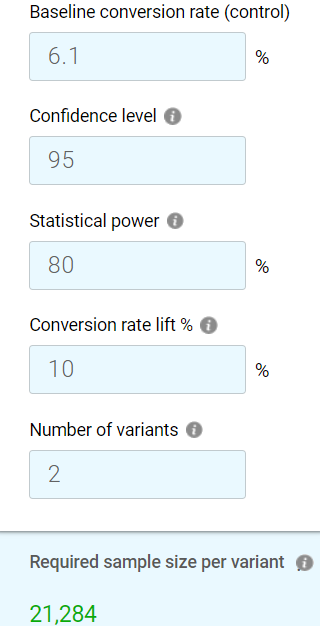

За допомогою [калькулятора](https://cxl.com/ab-test-calculator/) для розрахунку розміру вибірки для A/B тестів визначили, що нам потрібно приблизно 21 284 користувачі для виявлення мінімальної зміни в конверсії.

### Audience and Duration

Учасники тесту будуть нові користувачі застосунку, які досягли екрану з пропозицією підписки після онбордингу, двох груп: 1) Група A. Користувачі, які встановили застосунок в період, коли був запущений тест (цим користувачам ми пропонуємо купити підписку за 4.99, щоб отримати доступ до преміум-функцій застосунку). 2) Група B. Користувачі, що встановили версію застосунку, в якій реалізовано A/B тест (пропонуємо ту ж підписку, але з припискою про те, що це пропозиція зі знижкою 50%).

Користувач повинен бути новачком і перейти на цей екран. Не варто включати в тест користувачів, які вже мають підписку або відмовились від неї раніше.

Для розрахунку тривалості тесту ми скористаємося такими параметрами:

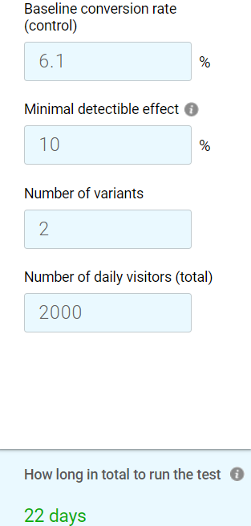

Враховуючи, що кожного дня застосунок встановлюють близько 2 тис. користувачів, за допомогою [калькулятора](https://cxl.com/ab-test-calculator/) визначили, що проводимо тест 22 дні, розбивка становитиме 50:50.

### Potential outcomes

Якщо конверсія до підписки в групі обробки збільшується на рівні значущості 5% і з потужністю тесту 80% та інші метрики не мають статистично негативного впливу, ми розглянемо можливість впровадження нового дизайну.

Якщо конверсія знижується зі статистичною значущістю в групі обробки, або інші важливі метрики негативно впливають, ми не впроваджуватимемо новий дизайн.

Якщо немає статистично значущих результатів тесту, ми оцінимо результати та розглянемо можливі покращення альтернативного дизайну перед повторним тестуванням. Можна спробувати інший варіант, наприклад, змінити ціну, знижку або вміст пропозиції. У разі успіху також можливо розглянути подальше вдосконалення та оптимізацію нового дизайну для максимізації конверсії та доходу.

### Conclusions

```python
import numpy as np
import pandas as pd
from scipy import stats
import matplotlib.pyplot as plt
import seaborn as sns
```

```python
test_data = pd.read_csv('ab_test_data.csv')
```

```python
test_data['date'] = pd.to_datetime(test_data['timestamp']).dt.date
test_data.head()
```

|  | user_id | timestamp | test_group | conversion | date |
| --- | --- | --- | --- | --- | --- |
| 0 | 7f6833e6-1141-4f20-b4b2-f1e31019b1fd | 2023-07-04 04:40:55.848109 | a | 0 | 2023-07-04 |
| 1 | e6a6e960-d3f3-4074-a516-ba1e609b211e | 2023-07-06 00:26:45.486187 | b | 0 | 2023-07-06 |
| 2 | 4d3fbfa5-6847-410a-bac2-477f01d5f400 | 2023-07-10 20:24:33.639464 | b | 0 | 2023-07-10 |
| 3 | 361457d9-a044-48f7-981c-d67dc3861679 | 2023-07-20 07:04:49.957013 | b | 0 | 2023-07-20 |
| 4 | 285cd63d-7d03-427f-a062-1fa2dd2e77d6 | 2023-07-19 23:27:50.116680 | b | 0 | 2023-07-19 |

```python
test_data.groupby('test_group').describe()
```

| test_group | conversion count | conversion mean | conversion std | conversion min | conversion 25% | conversion 50% | conversion 75% | conversion max |
| --- | --- | --- | --- | --- | --- | --- | --- | --- |
| a | 10013.0 | 0.061021 | 0.239380 | 0.0 | 0.0 | 0.0 | 0.0 | 1.0 |
| b | 9985.0 | 0.089034 | 0.284806 | 0.0 | 0.0 | 0.0 | 0.0 | 1.0 |

```python
print("Count of conversions in groups A and B:")
test_data.groupby('test_group')['conversion'].sum()
```

```
Count of conversions in groups A and B:
```

```
test_group
a    611
b    889
Name: conversion, dtype: int64
```

```python
data_start = test_data['date'].min()
data_end = test_data['date'].max()
duration = (data_end - data_start).days
print(f"Test start: {data_start}, Test end: {data_end},  Duration: {duration} days")
```

```
Test start: 2023-07-03, Test end: 2023-07-25,  Duration: 22 days
```

```python
alpha = 0.01

statistic, pvalue = stats.ttest_ind(test_data[test_data['test_group'] == 'a']['conversion'],
                                    test_data[test_data['test_group'] == 'b']['conversion'],
                                    alternative='less')

print(f'T-test: t-statistic: {round(statistic, 2)}, p-value: {round(pvalue, 2)}')
if pvalue < alpha:
    print('The difference is statistically significant, Null Hypothesis is rejected.')
else:
    print('The difference is insignificant, Null Hypothesis cannot rejected.')
```

```
T-test: t-statistic: -7.53, p-value: 0.0
The difference is statistically significant, Null Hypothesis is rejected.
```

```python
alpha = 0.01

observed = pd.crosstab(test_data['test_group'].values, test_data['conversion'].values)

statistic, pvalue, dof, expected_values = stats.chi2_contingency(observed)

print(f'Chi-squared: t-statistic: {round(statistic, 2)}, p-value: {round(pvalue, 2)}')
if pvalue < alpha:
    print('The difference is statistically significant, Null Hypothesis is rejected.')
else:
    print('The difference is insignificant, Null Hypothesis cannot rejected.')
```

```
Chi-squared: t-statistic: 56.14, p-value: 0.0
The difference is statistically significant, Null Hypothesis is rejected.
```

```python
def statistic(x, y):
    return stats.ttest_ind(x, y).statistic

alpha = 0.05

x = test_data[test_data['test_group'] == 'a']['conversion']
y = test_data[test_data['test_group'] == 'b']['conversion']

results = stats.permutation_test((x, y), statistic, n_resamples=100)

print(f'Permutation test: statistic: {round(results.statistic, 2)}, p-value: {round(results.pvalue, 2)}')
if results.pvalue < alpha:
    print('The difference is statistically significant, Null Hypothesis is rejected.')
else:
    print('The difference is insignificant, Null Hypothesis cannot rejected.')
```

```
Permutation test: statistic: -7.53, p-value: 0.02
The difference is statistically significant, Null Hypothesis is rejected.
```

#### Conclusions

Отже, за будь-яким критерієм ми відкидаємо нульову гіпотезу про те, що наша конверсія не залежить від тестової групи, в яку потрапив користувач і можемо приймати альтернативний дизайн. Іншими словами, різниця між групами є статистично значущою і можна впроваджувати новий дизайн (зі знижкою), для зручності припускачи, що додаткові метрики не зазнали значних змін.

Цільова метрика, конверсія з інстала в підписку збільшилась на 45.9%, з 6.1% до 8.9%.

Також візуалізуємо результати тесту нижче.

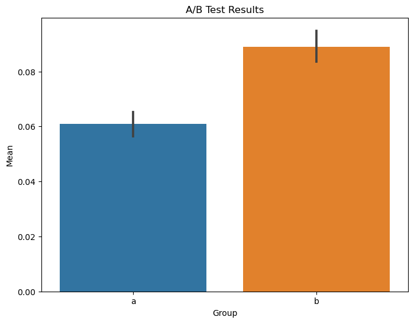

```python
plt.figure(figsize=(8, 6))
sns.barplot(x=test_data['test_group'],
            y=test_data['conversion'],
            errorbar=('ci', 95))
plt.title('A/B Test Results')
plt.xlabel('Group')
plt.ylabel('Mean')
plt.show()
```

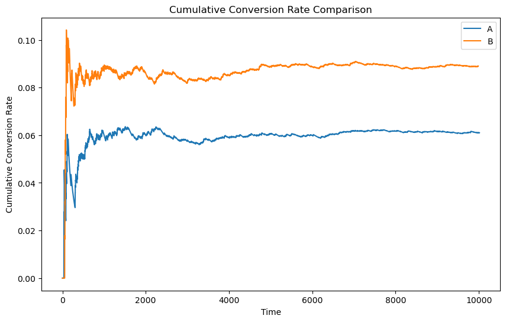

```python
test_data_sorted = test_data.sort_values(by='timestamp')

cumulative_metric_a = test_data_sorted[test_data_sorted['test_group'] == 'a']['conversion'].expanding().mean().reset_index(drop=True)
cumulative_metric_b = test_data_sorted[test_data_sorted['test_group'] == 'b']['conversion'].expanding().mean().reset_index(drop=True)

plt.figure(figsize=(10, 6))
plt.plot(cumulative_metric_a, label='A')
plt.plot(cumulative_metric_b, label='B')

plt.title('Cumulative Сonversion Rate Comparison')
plt.xlabel('Time')
plt.ylabel('Cumulative Сonversion Rate')

plt.legend()
plt.show()
```

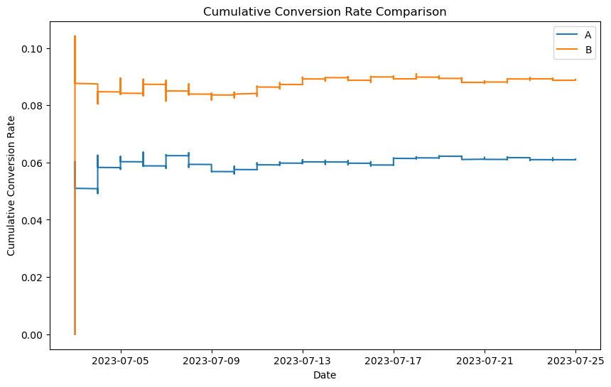

```python
test_data_sorted = test_data.sort_values(by='timestamp')

cumulative_metric_a = test_data_sorted[test_data_sorted['test_group'] == 'a'][['date', 'conversion']].set_index('date').expanding().mean()
cumulative_metric_b = test_data_sorted[test_data_sorted['test_group'] == 'b'][['date', 'conversion']].set_index('date').expanding().mean()

plt.figure(figsize=(10, 6))
plt.plot(cumulative_metric_a, label='A')
plt.plot(cumulative_metric_b, label='B')

plt.title('Cumulative Сonversion Rate Comparison')
plt.xlabel('Date')
plt.ylabel('Cumulative Сonversion Rate')

plt.legend()
plt.show()
```